# Using SAMBA

Created by Dr. Lauren J Beesley. Contact: lbeesley@umich.edu

04 October, 2019

In this vignette, we provide a brief introduction to using the R package *SAMBA* (sampling and misclassification bias adjustment). The purpose of this package is to provide resources for fitting a logistic regression for a binary outcome in the presence of outcome misclassification (in particular, imperfect sensitivity) along with potential selection bias. We will not include technical details about this estimation approach and instead focus on implementation. For additional details about the estimation algorithm, we refer the reader to Beesley and Mukherjee (2020) in *UNDER REVIEW*.

## Model Structure

Let binary $D$ represent a patient’s true disease status for a disease of interest, e.g. diabetes. Suppose we are interested in the relationship between $D$ and and person-level information, $Z$. $Z$ may contain genetic information, lab results, age, gender, or any other characteristics of interest. We call this relationship the *disease mechanism* as in **Figure 1**.

Suppose we consider a large health care system-based database with the goal of making inference about some defined general population. Let $S$ indicate whether a particular subject in the population is sampled into our dataset (for example, by going to a particular hospital and consenting to share biosamples), where the probability of an individual being included in the current dataset may depend on the underlying lifetime disease status, $D$, along with additional covariates, $W$. $W$ may also contain some or all adjustment factors in $Z$. In the EHR setting, we may often expect the sampled and non-sampled patients to have different rates of the disease, and other factors such as patient age, residence, access to care and general health state may also impact whether patients are included in the study base or not. We will call this mechanism the *selection mechanism.*

Instances of the disease are recorded in hospital or administrative records. We might expect factors such as the patient age, the length of follow-up, and the number of hospital visits to impact whether we actually *observe/record* the disease of interest for a given person. Let $D^*$ be the *observed* disease status. $D^*$ is a potentially misclassified version of $D$. We will call the mechanism generating $D^*$ the *observation mechanism.* We will assume that misclassification is primarily through underreporting of disease. In other words, we will assume that $D^*$ has perfect specificity and potentially imperfect sensitivity with respect to $D$. Let $X$ denote patient and provider-level predictors related to the true positive rate (sensitivity).

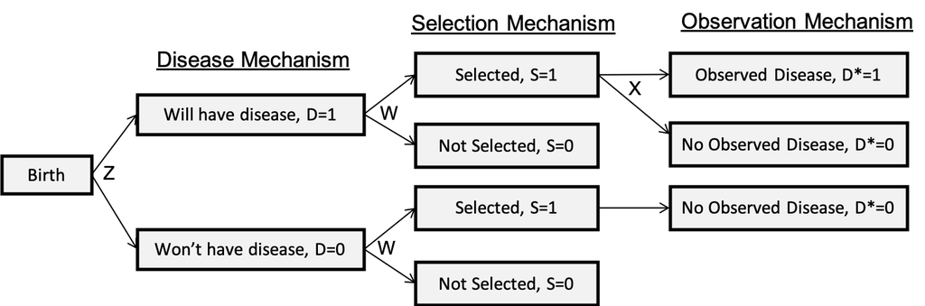

Figure 1: Model Structure

We express the conceptual model as follows:

$$\text{Disease Model}: \text{logit}(P(D=1 \vert Z; \theta )) = \theta_0 + \theta_Z Z$$
$$\text{Selection Model}: P(S=1 \vert D, W; \phi )$$
$$\text{Sensitivity/Observation Model}: \text{logit}(P(D^*=1 \vert D=1, S=1, X; \beta)) = \beta_0 + \beta_X X$$

## Simulate Data

```r
library(SAMBA)
options(warn = -1)
mSample = function(Y){return(sample(x=c(0,1), size = 1, prob = c(1-Y,Y)))}
expit = function(x){return(exp(x)/(1+exp(x)))}
logit = function(x){log(x/(1-x))}
Nobs = 5000

### Generate Predictors and Follow-up Information
set.seed('1234')
COV = MASS::mvrnorm(n=Nobs, mu = c(0,0,0), Sigma = rbind(c(1,0,0.4), c(0,1,0), c(0.4,0,1)))
DAT = data.frame(Z = COV[,1], X = COV[,2], W = COV[,3])

### Generate random uniforms
set.seed('5678'); U1 = runif(n = Nobs, min = 0, max = 1);
set.seed('4321'); U2 = runif(n = Nobs, min = 0, max = 1);
set.seed('8765'); U3 = runif(n = Nobs, min = 0, max = 1);

### Generate Disease Status
DISEASE = expit(-2+0.5*DAT$Z)
DAT$D = ifelse(DISEASE > U1, 1, 0) #apply(matrix(probD),1, mSample)

### Relate W and D
DAT$W = DAT$W + 1*DAT$D

### Generate Misclassification
SENS = expit(-0.4 + 1*DAT$X)
SENS[DAT$D == 0] = 0
DAT$Dstar = ifelse(SENS > U2, 1, 0)# apply(matrix(prob1),1, mSample)

### Generate Sampling Status
SELECT = expit(-0.6 +1*DAT$D + 0.5*DAT$W )
DAT$S = ifelse(SELECT > U3, 1, 0) #apply(matrix(prob1),1, mSample)

### Observed Data
DAT_SUB = DAT[DAT$S==1,]

### True marginal sampling ratio
prob1 = expit(-0.6 +1*1 + 0.5*DAT$W )
prob0 = expit(-0.6 +1*0 + 0.5*DAT$W )
r_marg_true = mean(prob1[DAT$D==1])/mean(prob0[DAT$D==0])

### True inverse probability of sampling weights
prob_WD =expit(-0.6 +1*DAT_SUB$D + 0.5*DAT_SUB$W )
weights = length(DAT_SUB[,1])*(1/prob_WD)/(sum(1/prob_WD))

### True associations with D in population
trueX = glm(D~X, family = binomial(), data = DAT)
trueZ = glm(D~Z, family = binomial(), data = DAT)

### Initial Parameter Values
fitBeta = glm(Dstar~X, family = binomial(),data = DAT_SUB)
fitTheta = glm(Dstar~Z, family = binomial(), data = DAT_SUB)
```

## Estimating Sensitivity

In Beesley and Mukherjee (2020) (*UNDER REVIEW*), we develop several strategies for estimating sensitivity as a function of covariates X. Here, we apply several of the proposed strategies.

```r
### Using marginal sampling ratio r and P(D=1)
sens1 = sensitivity(Z = DAT_SUB$Z, X = DAT_SUB$X, Dstar = DAT_SUB$Dstar,
                    r = r_marg_true, prev = mean(DAT$D))
### Using inverse probability of selection weights and P(D=1)
sens2 = sensitivity(Z = DAT_SUB$Z, X = DAT_SUB$X, Dstar = DAT_SUB$Dstar,
                    weights = weights, prev = mean(DAT$D))
### Using marginal sampling ratio r and P(D=1|X)
sens3 = sensitivity(Z = DAT_SUB$Z, X = DAT_SUB$X, Dstar = DAT_SUB$Dstar,
                    r = r_marg_true, prev = predict(trueX, newdata = DAT_SUB, type = 'response'))
### Using inverse probability of selection weights and P(D=1|X)
sens4 = sensitivity(Z = DAT_SUB$Z, X = DAT_SUB$X, Dstar = DAT_SUB$Dstar,
                    weights = weights, prev = predict(trueX, newdata = DAT_SUB, type = 'response'))
```

## Estimating log-odds ratio for D|Z

We propose several strategies for estimating the association between D and Z from a logistic regression model in the presence of different biasing factors. Below, we provide code for implementing these methods.

```r
### Approximation of D*|Z
approx1 = approxdist(Z = DAT_SUB$Z, Dstar = DAT_SUB$Dstar, weights = weights, c_marg = sens1$c_marg)

### Non-logistic link function method
nonlog1 = nonlogistic(Z = DAT_SUB$Z, X = DAT_SUB$X, Dstar = DAT_SUB$Dstar, weights = weights, c_X = sens3$c_X)

### Direct observed data likelihood maximization with fixed intercept
starting = as.numeric(c(coef(fitTheta), logit(sens1$c_marg),coef(fitBeta)[2]))
fit = obsloglik(Z=DAT_SUB$Z, X=DAT_SUB$X, Dstar  = DAT_SUB$Dstar,
                   param_current = starting,
                   beta0_fixed = logit(sens1$c_marg), weights = weights)
Info = obsloglik_var(theta = fit$param[1:2], beta = fit$param[3:4],
                    X=DAT_SUB$X, Z = DAT_SUB$Z, Dstar = DAT_SUB$Dstar, getInfo = TRUE, weights = weights)
obsloglik1 = list(param = fit$param, variance = diag(solve(-Info[c(1,2,4),c(1,2,4)])))
```

## Plotting sensitivity estimates

**Figure 2** shows the estimated individual-level sensitivity values when the marginal sampling ratio (r-tilde) is correctly specified. We can see that there is strong concordance with the true sensitivity values.

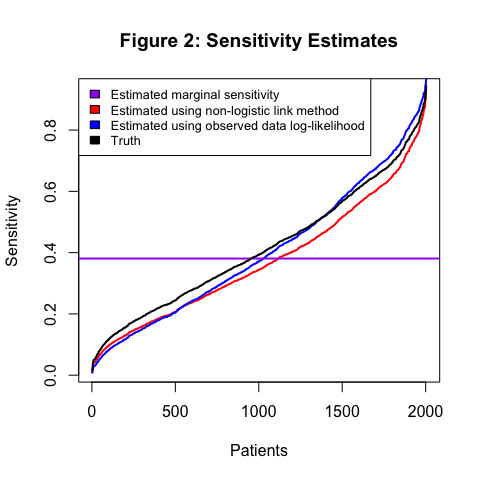

**Figure 3** shows the estimated individual-level sensitivity values across different marginal sampling ratio values. In reality, we will rarely know the truth, and this strategy can help us obtain reasonable values for sensitivity across plausible sampling ratio values.

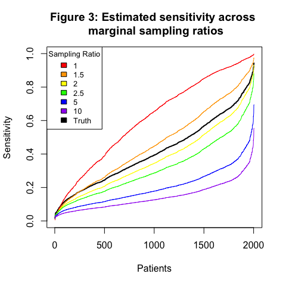

## Plotting log-odds ratio estimates

**Figure 4** shows the estimated log-odds ratio relating $D$ and $Z$ for the various analysis methods. Uncorrected (complete case with misclassified outcome) analysis produces bias, and some methods reduce this bias. Recall, this is a single simulated dataset, and the corrected estimators may not always equal the truth for a given simulation. When $W$ and $D$ are independently associated, the method using the approximated $D^* \vert Z$ relationship and marginal sensitivity can sometimes perform poorly.

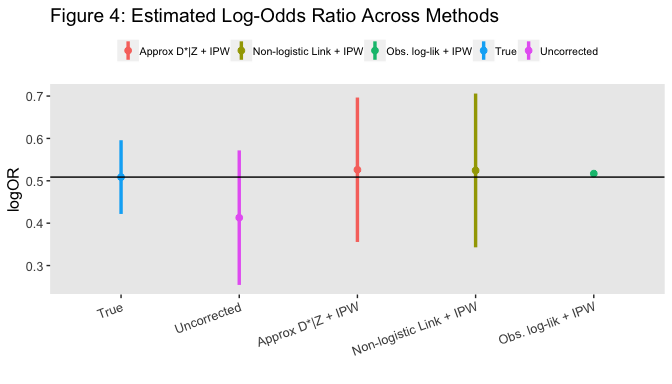